# Global Tempature Anomaly

Replicating NASA’s Graph

William Komu

2023-02-12

## Import data and tidy it

```r
t_diff <- read_csv("/home/iamlnx/Documents/GitHub/nasoma_R/climate/data/GLB.Ts+dSST.csv", skip = 1, na = "***") %>%
    select(Year, "J-D") %>%
    rename(t_diff = "J-D") %>%
    clean_names()
```

## Plot

This plot mimics NASA’s [GLOBAL LAND-OCEAN TEMPERATURE INDEX](https://climate.nasa.gov/vital-signs/global-temperature/). The graph indicates the deviation of the global avg temperature from a normalised mean!

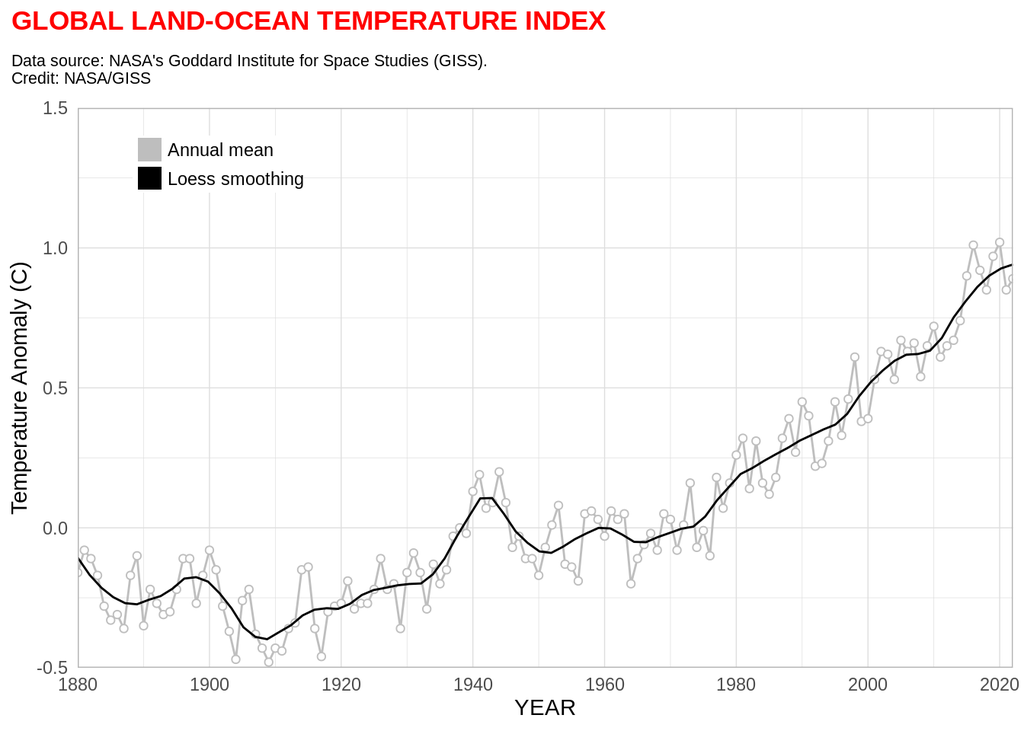

```
   🔥🔥 🔥 #EarthOnFire 🔥 🔥🔥
```

```r
t_diff %>%
    ggplot(aes(year, t_diff)) +
    geom_line(aes(color = "1"), size = 0.5, show.legend = FALSE) +
    geom_point(fill = "white", aes(color = "1"), shape = 21, show.legend = TRUE) +
    geom_smooth(aes(color = "2"), span = .15, size = 0.5, se = FALSE, show.legend = FALSE) +
    theme_light() +
    scale_x_continuous(breaks = seq(1880, 2020, 20), expand = c(0, 0)) +
    scale_y_continuous(limits = c(-0.5, 1.5), expand = c(0, 0)) +
    scale_color_manual(
        name = NULL,
        breaks = c(1, 2),
        values = c("gray", "black"),
        labels = c("Annual mean", "Loess smoothing"),
        guide = guide_legend(override.aes = list(shape = 15, size = 5))
    ) +
    labs(
        title = "GLOBAL LAND-OCEAN TEMPERATURE INDEX",
        x = "YEAR",
        y = "Temperature Anomaly (C)",
        subtitle = "Data source: NASA's Goddard Institute for Space Studies (GISS).\nCredit: NASA/GISS"
    ) +
    theme(
        axis.ticks = element_blank(),
        plot.title.position = "plot",
        plot.title = element_text(margin = margin(b = 10), color = "red", face = "bold"),
        plot.subtitle = element_text(size = 8, margin = margin(b = 10)),
        legend.position = c(0.15, 0.9),
        legend.title = element_text(size = 0),
        legend.key.height = unit(10, "pt"),
        legend.margin = margin(0, 0, 0)
    )
```

# Interpretation of the Code Chuck

## Scale the x and y-axis

### x-axis

I was looking into this the other day. All my plots have bothered me… for not capturing all the x values, which means some of the latter years are ignored! To fix, let’s use:

```
    `scale_x_continuous(breaks = seq(1880, 2020, 20), expand = c(0, 0))`
```

The other part `expand = c(0, 0)` instructs R to get rid of spaces between the plot’s edges!

### y-axis

The layer `scale_y_continuous(limits = c(-0.5, 1.5))`sets the `ymin=-0.5` and `ymax=1.5`! I will look to using the ymin and ymax syntax later! I think it is used. By the scale_y_continuous is much better for me coz I have the one for colors mastered.

### Showcasing the depth of the `theme()` function

The `theme()` code will allow us to

- Remove the ticks!

  ```
    axis.ticks = element_blank()
  ```

- Align tittle left extreme edge:

  ```
    plot.title.position = "plot"
  ```

***Without this setup, the title will align with the left border of the chart area!**

- Add space between title and subtitle, color title red and bold it:

  ```
    plot.title = element_text(margin = margin(b = 10), color = "red", face = "bold")
  ```

- Size the subtitle, create a buffer space between it it and top of chart area

  ```
    plot.subtitle = element_text(size = 8, margin = margin(b = 10))
  ```

- Place legend on the top left side of the chart area

  ```
    legend.position = c(0.15, 0.9)
  ```

- A Trick for something! HAHA

  ```
    legend.title = element_text(size = 0)
  ```

- Fix legend space between legend keys

  ```
    legend.key.height = unit(10, "pt")
  ```

- Refine legend postion relative to the left, top edges